# Untitled

Peter Bruno

May 15, 2016

## Background and Overview

This project is a final report for the Practical Machine Learning course. The goal of the project is to determine the manner in which participants performed exercises. A training set of data will be used with a learning algorithm to determine which types of activities the test data falls into.

Data collected from personal exercise trackers can be gathered easily. The data is easily quantified in terms of how much of an activity is done, but not how well the activity is completed. More information about the specifics of the experiment can be found on the website here: http://groupware.les.inf.puc-rio.br/har.

# Loading and Exploratory Analysis

Specific R Libraries are needed for the analysis, some of the libraries called will also load others that are used. Specific packages are caret, randomForest, rpart.

The data is previously downloaded and set in the current working directory. Then read in using csv read commands where we clearly mark NAs in the data.

```r
train<-read.csv("pml-training.csv",header=TRUE,na.strings=c("NA","#DIV/0",""))
test<-read.csv("pml-testing.csv",header=TRUE,na.strings=c("NA","#DIV/0",""))
```

It is important to start cleaning up the data by removing data with near zero variance. and removing the first column as it is unnecessary. It is also helpful to remove the variables with more than two thirds NA, so variables with more than 66% NA are removed as well

```r
nzv <- nearZeroVar(train, saveMetrics=TRUE)
train <- train[,nzv$nzv==FALSE]

train <- train[c(-1)]

train2 <- train
for(i in 1:length(train)) {
    if( sum( is.na( train[, i] ) ) /nrow(train) >= .66) {
        for(j in 1:length(train2)) {
            if( length( grep(names(train[i]), names(train2)[j]) ) == 1)  {
                train2 <- train2[ , -j]
            }
        }
    }
}

# Set back to the original variable name
train <- train2
rm(train2)
```

Then partitioning out a training and test dataset to use before the final test set.

```r
set.seed(100)
intrain <- createDataPartition(train$classe, p=0.6, list=FALSE)
mytrain <- train[intrain, ]
mytest <- train[-intrain, ]
dim(mytrain); dim(mytest)
```

```
## [1] 11776    58
```

```
## [1] 7846   58
```

Transform the datasets so that they match appropriately.

```r
clean1 <- colnames(mytrain)
clean2 <- colnames(mytrain[, -58])  # remove the classe column
mytest <- mytest[clean1]         # allow only variables in mytest that are also in mytrain
test <- test[clean2]             # allow only variables in testing that are also in mytrain

dim(mytest)
```

```
## [1] 7846   58
```

The data has to be coerced into the same type for proper analysis

```r
for (i in 1:length(test) ) {
    for(j in 1:length(train)) {
        if( length( grep(names(train[i]), names(test)[j]) ) == 1)  {
            class(test[j]) <- class(mytrain[i])
        }
    }
}

# To get the same class between test and mytrain
test <- rbind(mytrain[2, -58] , test)
test <- test[-1,]
```

```r
modFit <- rpart(classe ~ ., data=mytrain, method="class")
```

```r
predictions <- predict(modFit, mytest, type = "class")
cmtree <- confusionMatrix(predictions, mytest$classe)
cmtree
```

```
## Confusion Matrix and Statistics
##
##           Reference
## Prediction    A    B    C    D    E
##          A 2148   61    6    3    0
##          B   67 1306  130   63    0
##          C   17  144 1186  132   46
##          D    0    7   31  885   83
##          E    0    0   15  203 1313
##
## Overall Statistics
##
##                Accuracy : 0.8715
##                  95% CI : (0.8639, 0.8789)
##     No Information Rate : 0.2845
##     P-Value [Acc > NIR] : < 2.2e-16
##
##                   Kappa : 0.8374
##  Mcnemar's Test P-Value : NA
##
## Statistics by Class:
##
##                      Class: A Class: B Class: C Class: D Class: E
## Sensitivity            0.9624   0.8603   0.8670   0.6882   0.9105
## Specificity            0.9875   0.9589   0.9477   0.9816   0.9660
## Pos Pred Value         0.9684   0.8340   0.7777   0.8797   0.8576
## Neg Pred Value         0.9851   0.9662   0.9712   0.9414   0.9796
## Prevalence             0.2845   0.1935   0.1744   0.1639   0.1838
## Detection Rate         0.2738   0.1665   0.1512   0.1128   0.1673
## Detection Prevalence   0.2827   0.1996   0.1944   0.1282   0.1951
## Balanced Accuracy      0.9749   0.9096   0.9073   0.8349   0.9382
```

Plotting some results from our Decision Tree Confusion Matrix

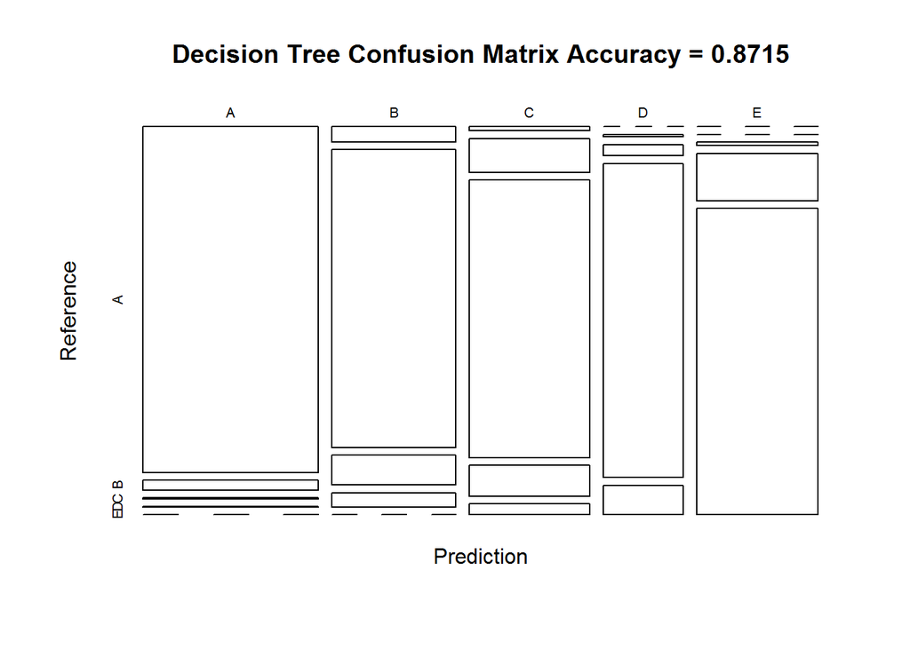

```r
plot(cmtree$table, col = cmtree$byClass, main = paste("Decision Tree Confusion Matrix Accuracy =", round(cmtree$overall['Accuracy'], 4)))
```

# Random Forest Prediction

```r
set.seed(101)
modFit2 <- randomForest(classe ~ ., data=mytrain)
prediction2 <- predict(modFit2, mytest, type = "class")
cmrf <- confusionMatrix(prediction2, mytest$classe)
cmrf
```

```
## Confusion Matrix and Statistics
##
##           Reference
## Prediction    A    B    C    D    E
##          A 2231    0    0    0    0
##          B    1 1518    1    0    0
##          C    0    0 1366    1    0
##          D    0    0    1 1285    3
##          E    0    0    0    0 1439
##
## Overall Statistics
##
##                Accuracy : 0.9991
##                  95% CI : (0.9982, 0.9996)
##     No Information Rate : 0.2845
##     P-Value [Acc > NIR] : < 2.2e-16
##
##                   Kappa : 0.9989
##  Mcnemar's Test P-Value : NA
##
## Statistics by Class:
##
##                      Class: A Class: B Class: C Class: D Class: E
## Sensitivity            0.9996   1.0000   0.9985   0.9992   0.9979
## Specificity            1.0000   0.9997   0.9998   0.9994   1.0000
## Pos Pred Value         1.0000   0.9987   0.9993   0.9969   1.0000
## Neg Pred Value         0.9998   1.0000   0.9997   0.9998   0.9995
## Prevalence             0.2845   0.1935   0.1744   0.1639   0.1838
## Detection Rate         0.2843   0.1935   0.1741   0.1638   0.1834
## Detection Prevalence   0.2843   0.1937   0.1742   0.1643   0.1834
## Balanced Accuracy      0.9998   0.9998   0.9992   0.9993   0.9990
```

Showing the plot of our random forests

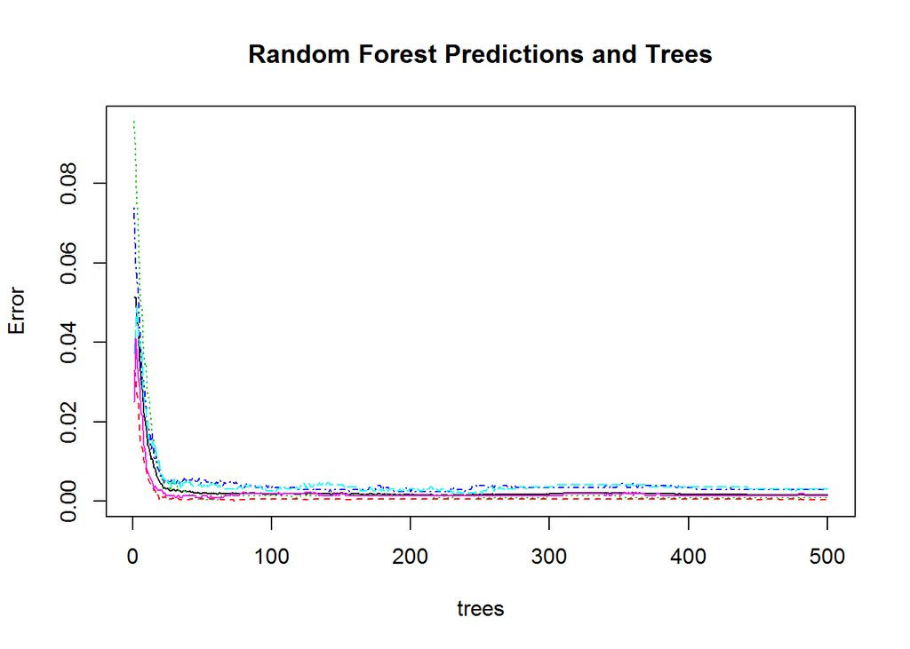

```r
plot(modFit2,main="Random Forest Predictions and Trees")
```

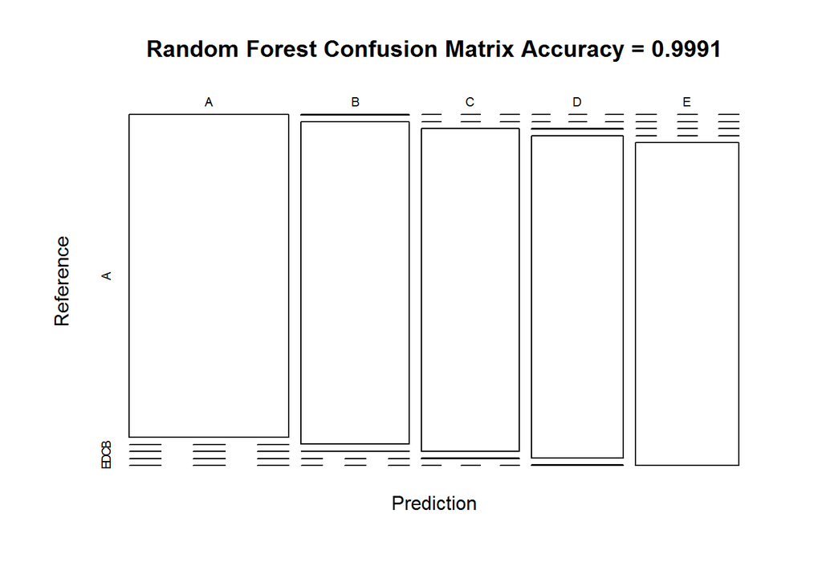

```r
plot(cmrf$table, col = cmtree$byClass, main = paste("Random Forest Confusion Matrix Accuracy =", round(cmrf$overall['Accuracy'], 4)))
```

The Random Forests give a higher accuracy with 0.9991 than the Decision Tree (0.8715) method so that is the method used on the final test data.

# Predicting Results on Final Test Data

```r
prediction2 <- predict(modFit2, test, type = "class")
prediction2
```

```
##  2  3 41  5  6  7  8  9 10 11 12 13 14 15 16 17 18 19 20 21
##  B  A  B  A  A  E  D  B  A  A  B  C  B  A  E  E  A  B  B  B
## Levels: A B C D E
```

Our Final results are correct based on the quiz and so we can also assume our predictive model is reasonably correct.